# Introduction to programming in R

Julia Rühle & Leone Albinati

25th-27th of November 2024

# 1 Course organization

# 2 Data types in R

Every object in R has a data type

- Numeric (integer or double): any number
- Character: text objects
- Logical: TRUE or FALSE

To check what is the data type of an object, we can use the function **mode()**

```r
# let's create different objects and check for their type
type1 <- 2
type2 <- "banana"
type3 <- "5"
type4 <- TRUE

# check the data type of the different objects - example type1
mode(type1)
# Can we multiply type1 and type3?
```

Checking for data types is important, especially when you will work with more complex data structures

# 3 Data structures

The main data structures in R are:

- Vectors
- Matrices
- Data Frames

There are also many other data structures (like factors and lists) that will not be discussed in this course.

> **Important note**

> In this section, we will describe the main data structures used in R and we will show you how to handle and manipulate these structures using **basic R language**. As of today, an amazing set of packages to work and manipulate data structures has been developed, called **tidyverse**. Many codes are written using tidyverse and often ChatGPT and other language models suggest codes using tidyverse. Moreover, the well known package **ggplot** (the reason many of you are here?) is developed inside tidyverse. The way tidyverse handles data structures is different from how we do it with basic R. Still, **knowing basic R is important** (to properly know the language and to understand other people’s scripts); therefore we decided to dedicate this session to learn how to handle data structures with basic R, and from tomorrow on we’ll move to tidyverse.

## 3.1 Vectors

Vectors are one-dimension sequences of data elements of the **same type**.

### 3.1.1 Creating a vector

- To create a vector, we use the function **c()** - combine.
- The elements inside the c() have to be separated by commas.

```r
# let's create a vector of numbers
my_first_vec <- c(1,3,5,7,9)
mode(my_first_vec)

# for numerical intervals, we can create a vector using the : (colon)
# the interval includes the extremes!
interval_vec <- 1:5
# this is the same as doing
interval_vec <- c(1,2,3,4,5)

# let's create a character vector - each of the character elements has to be included in quotes!
# spaces between commas do not change the meaning
character_vec <- c("lion", "zebra", "elephant")
mode(character_vec)

# what happens if we don't put the quotes?
character_vec2 <- c(lion, zebra, elephant)

# what happens if we create a "mixed" vector?
mixed_vec <- c("lion", TRUE, 1)
mode(mixed_vec)
```

- tip1: to add the quotes you can select the elements and then press the quote key
- tip2: single quotes can also be used, but in R is preferable to use the double quotes

### 3.1.2 Combining vectors

Different vectors can be combined

```r
# let's create the vector planets
gas_planets <- c("Jupiter", "Saturn", "Uranus", "Neptune")
terrestrial_planets <- c("Mercury", "Venus", "Earth", "Mars")
all_planets <- c(terrestrial_planets,gas_planets)

# we can also combine vectors and single elements
really_all_planets <- c(all_planets,"Pluto")

# how many elements are there in the vector all_planets?
length(all_planets)
```

### 3.1.3 Vector manipulation

Learning vector manipulation is essential in R because it forms the foundation for handling more complex data structures, such as data frames and matrices, which is crucial for data analysis and visualization.

- We can name vectors - just for you to know but not that useful

```r
# let's create a vector of RNA counts - a numeric vector
gene_counts <- c(125,36,42,20)

# let's name each element with the type of gene it belongs to - a character vector
gene_types <- c("protein_coding","lncRNA","pseudogene","miRNA")

# let's assign the gene type as names of the vector
names(gene_counts) <- gene_types
gene_counts

# it did not change mode - the names are not part of the vector
mode(gene_counts)
```

- We can **extract elements** from a vector using **their position (index)** inside the vector
- To extract elements in R we use the square brakets **[]** - common to other languages

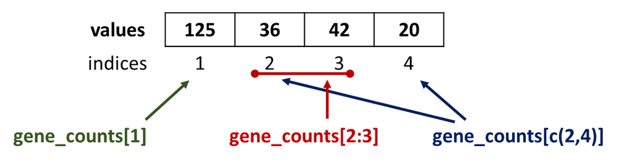

```r
# extract the elements
gene_counts[1]
gene_counts[2:3]
gene_counts[c(2,4)]

# we can extract and reassign if we want
first_element <- gene_counts[1]
```

- We can also reassign a specific vector element or remove it from the vector

```r
# we realized we made a mistake and eant to change the third element
gene_counts[3] <- 10
# check gene_counts
gene_counts

# now we want to remove the third element
gene_counts <- gene_counts[-3]
```

- **IMPORTANT**: showing in console and reassigning

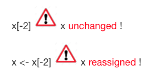

#### 3.1.3.1 HANDS-ON

1. From the gene_counts vector, extract the first and third element and multiply them.
2. Then, remove the second element and assign to a new object **mod_vec**.
3. On this new vector, extract the first and third element and multiply them. Does the result change?

### 3.1.4 Numeric vector manipulation based on content

- Manipulating vectors based on indices can be useful, but most of the times we would **manipulate them based on their content** (i.e.select all the elements grater than x, select only the ones equal to y)

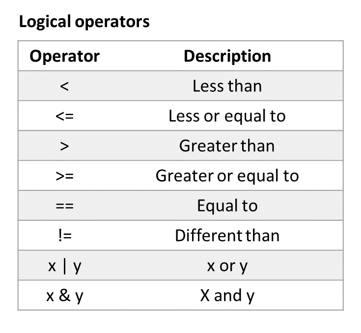

- Example: we want to know which elements of a vector are equal to 7 and which are greater

```r
# let's create a numeric vector containing the values 3,11,2,7,9
my_vector <- c(3,11,2,7,9)

# which elements are equal to 7?
my_vector == 7

# which elements are greater than 7?
my_vector > 7
```

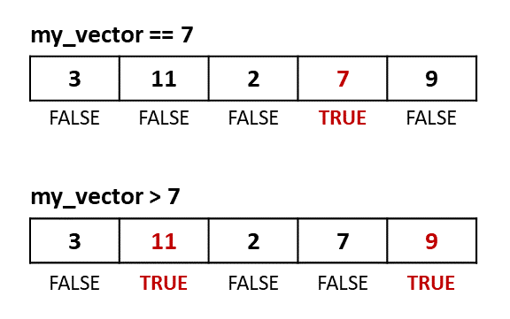

- We can use this conditions to extract elements from a vector

```r
# let's extract all the elements that are smaller or equal than 9
# check the condition
my_vector <= 9

# extract the subvector that complied the condition (so extract only the TRUE elements)
my_vector[my_vector<=9]

# instead of using the index of the vector, we use the condition

# assign the output
smaller_9 <- my_vector[my_vector<=9]
```

- Of course, we can combine multiple conditions

```r
# extract the elements greater than 3 and smaller than 11
my_vector[my_vector>3 & my_vector<11]
```

#### 3.1.4.1 HANDS-ON

- Given a vector of people’s height

```r
height <- c(182,161,158,179,173,191,181,162,173)
```

- Create a vector namesd **tall** with all the people higher than 170.
- Create a vector named **extreme** with all the people higher than 190 or shorter than 160.

### 3.1.5 Operations with vector

- We can make standard operations with vectors

```r
# all of our friends from before are wearing 10 cm heels
height + 10
height_w_heels <- height + 10

# ten is added to each element of the vector
# this can be done with all the operations (square root, subtractions etc)
```

- We can make operations between vectors of the same length

```r
vec1 <- c(2,5,7,9)
vec2 <- 2:5

vec1*vec2
vec1-vec2
```

- … and also between vectors of different length (try not to)

```r
vec1 <- c(2,5,7,9)
vec2 <- 2:3

vec1*vec2
vec1-vec2
```

- We can compute the most basic summary statistics

```r
mean(vec1)
median(vec1)
min(vec1)
max(vec1)
summary(vec1) # useful overview
```

#### 3.1.5.1 HANDS-ON

- Based on our height vector, what is the mean height of the people that are shorter than 180cm?
- You can do it in two steps, first extracting the people shorter than 180 and then computing the mean.